# Ray Unit 3 - Sharded Data

Pandas puts an entire DF in RAM. What if the data is too big?

Ray shards the data into blocks while keeping a pandas-like API.

Popular alternatives: Spark, Dask, Daft.

## Setup

Use the same `22971-ray` environment and notebook kernel as the previous units.

```python
import math
import time
from pathlib import Path

import numpy as np
import pandas as pd
import ray
from IPython.display import display
from ray.data.aggregate import AggregateFnV2, Count, Mean, Sum
from ray.data.block import BlockAccessor

ray.shutdown()
ray.init(
    ignore_reinit_error=True,
    include_dashboard=False,
    log_to_driver=False,
    logging_level='ERROR',
)
print('Ray version:', ray.__version__)
print('Ray resources:', ray.cluster_resources())
```

```
Ray version: 2.54.0
Ray resources: {'object_store_memory': 4911500083.0, 'GPU': 1.0, 'memory': 11460166861.0, 'node:__internal_head__': 1.0, 'accelerator_type:G': 1.0, 'node:127.0.0.1': 1.0, 'CPU': 12.0}
```

## 0. Generate data

We generate synthetic gameplay telemetry data with these columns:

```
| Column | Type |
|---|---|
| `event_ts` | `timestamp[ns]` |
| `player_id` | `int32` |
| `session_id` | `int32` |
| `region` | `string` |
| `platform` | `string` |
| `event_type` | `string` |
| `level_id` | `int16` |
| `latency_ms` | `int32` |
| `spend_usd` | `float` |
| `is_test_user` | `bool` |
| `payload_blob` | `string` |
```

- `payload_blob` is a long nonsense string that makes each row artificially wide.
- We save the dataset to `...\fake_data\part-XX.parquet`.
- The dataset is split into `NUM_SHARDS` parquet shards.

### Helper functions

```python
SEED = 0
N_ROWS = 60_000
NUM_SHARDS = 8
PAYLOAD_CHARS = 2_000 #2 KB per row
DATA_DIR = 'fake_data'
OUT_DIR = 'output'

REGIONS = np.array(['NA', 'EU', 'APAC', 'LATAM', 'MEA'])
PLATFORMS = np.array(['pc', 'console', 'mobile'])
EVENT_TYPES = np.array(['match_start', 'match_end', 'quest', 'purchase', 'crash', 'chat'])


def build_payload_column(n_rows, payload_chars=PAYLOAD_CHARS):
    seeds = pd.Series(np.arange(n_rows), dtype='int64').map(
        lambda i: f'blob-{i:07d}-{(i * 2654435761) & 0xFFFFFFFF:08x}'
    )
    return seeds.str.pad(payload_chars, side='right', fillchar='x')


def build_telemetry_frame(n_rows=N_ROWS, seed=SEED, payload_chars=PAYLOAD_CHARS):
    rng = np.random.default_rng(seed)
    event_type = rng.choice(EVENT_TYPES, size=n_rows, p=[0.28, 0.22, 0.25, 0.07, 0.03, 0.15])
    event_ts = pd.Timestamp('2025-01-01') + pd.to_timedelta(
        rng.integers(0, 14 * 24 * 60 * 60, size=n_rows),
        unit='s',
    )
    latency_ms = np.round(
        rng.gamma(shape=2.4, scale=32.0, size=n_rows) + rng.integers(5, 25, size=n_rows)
    ).astype('int32')
    latency_ms[event_type == 'crash'] *= 2

    spend_usd = np.zeros(n_rows, dtype='float32')
    purchase_mask = event_type == 'purchase'
    spend_usd[purchase_mask] = rng.uniform(0.99, 59.99, size=purchase_mask.sum()).round(2)

    frame = pd.DataFrame(
        {
            'event_ts': event_ts,
            'player_id': rng.integers(10_000, 90_000, size=n_rows, dtype=np.int32),
            'session_id': rng.integers(100_000, 900_000, size=n_rows, dtype=np.int32),
            'region': rng.choice(REGIONS, size=n_rows, p=[0.36, 0.27, 0.22, 0.10, 0.05]),
            'platform': rng.choice(PLATFORMS, size=n_rows, p=[0.42, 0.18, 0.40]),
            'event_type': event_type,
            'level_id': rng.integers(1, 60, size=n_rows, dtype=np.int16),
            'latency_ms': latency_ms,
            'spend_usd': spend_usd,
            'is_test_user': rng.random(n_rows) < 0.02,
            'payload_blob': build_payload_column(n_rows, payload_chars),
        }
    )

    return frame.reset_index(drop=True)


def write_parquet_shards(frame, out_dir, num_shards=NUM_SHARDS):
    out_dir = Path(out_dir)
    out_dir.mkdir(parents=True, exist_ok=True)
    rows_per_shard = math.ceil(len(frame) / num_shards)
    for shard_id in range(num_shards):
        start = shard_id * rows_per_shard
        stop = min((shard_id + 1) * rows_per_shard, len(frame))
        shard = frame.iloc[start:stop]
        if shard.empty:
            continue
        shard.to_parquet(out_dir / f'part-{shard_id:02d}.parquet', index=False)


def enrich_batch(batch):
    batch = batch.copy()
    batch['hour_of_day'] = batch['event_ts'].dt.hour.astype('int8')
    batch['is_purchase'] = batch['event_type'].eq('purchase')
    batch['is_crash'] = batch['event_type'].eq('crash')
    batch['latency_band'] = pd.cut(
        batch['latency_ms'],
        bins=[-1, 60, 120, 240, np.inf],
        labels=['fast', 'stable', 'slow', 'spiky'],
    ).astype('string')
    return batch
```

### Data generation

```python
workspace_dir = Path.cwd()
input_dir = workspace_dir / DATA_DIR
output_dir = workspace_dir / OUT_DIR

workspace_dir.mkdir(parents=True, exist_ok=True)

existing_shards = sorted(input_dir.glob('part-*.parquet'))
if existing_shards:
    print(f"Found {len(existing_shards)} existing parquet shards in {input_dir}; skipping generation.")
    telemetry_pdf = pd.concat((pd.read_parquet(path) for path in existing_shards), ignore_index=True)
else:
    telemetry_pdf = build_telemetry_frame()
    write_parquet_shards(telemetry_pdf, input_dir, num_shards=NUM_SHARDS)

display(telemetry_pdf.head())
size_bytes = telemetry_pdf.memory_usage(deep=True).sum()
print(f"size: {size_bytes / 1024**2:.2f} MiB")
```

```
Found 8 existing parquet shards in c:\Users\alter\OneDrive\Documents\GitHub\OU-22971-Toolbox\Ray\3_ray_data\fake_data; skipping generation.
```

|  | event_ts | player_id | session_id | region | platform | event_type | level_id | latency_ms | spend_usd | is_test_user | payload_blob |
| --- | --- | --- | --- | --- | --- | --- | --- | --- | --- | --- | --- |
| 0 | 2025-01-05 04:02:26 | 81408 | 502575 | APAC | pc | quest | 49 | 53 | 0.00 | False | blob-0000000-00000000xxxxxxxxxxxxxxxxxxxxxxxxx... |
| 1 | 2025-01-10 17:00:11 | 60826 | 556316 | APAC | console | match_start | 44 | 129 | 0.00 | False | blob-0000001-9e3779b1xxxxxxxxxxxxxxxxxxxxxxxxx... |
| 2 | 2025-01-07 21:20:43 | 82367 | 334510 | EU | pc | match_start | 20 | 100 | 0.00 | False | blob-0000002-3c6ef362xxxxxxxxxxxxxxxxxxxxxxxxx... |
| 3 | 2025-01-03 19:40:54 | 41559 | 168491 | EU | pc | match_start | 1 | 143 | 0.00 | False | blob-0000003-daa66d13xxxxxxxxxxxxxxxxxxxxxxxxx... |
| 4 | 2025-01-14 06:36:17 | 59378 | 497715 | EU | mobile | purchase | 7 | 133 | 2.09 | False | blob-0000004-78dde6c4xxxxxxxxxxxxxxxxxxxxxxxxx... |

```
size: 128.05 MiB
```

## 1. Ray Data mental model

#### A Ray `Dataset` feels a lot like a pandas `DataFrame` for the operations in this notebook.

```python
events_ds = ray.data.read_parquet(str(input_dir), override_num_blocks=NUM_SHARDS)
```

```
2026-05-14 13:10:41,711	INFO parquet_datasource.py:1079 -- Estimated parquet encoding ratio is 14.810.
2026-05-14 13:10:41,711	INFO parquet_datasource.py:1139 -- Estimated parquet reader batch size at 65218 rows
```

```python
events_ds.show(5)
```

[output not shown]

```
{'event_ts': Timestamp('2025-01-05 04:02:26'), 'player_id': 81408, 'session_id': 502575, 'region': 'APAC', 'platform': 'pc', 'event_type': 'quest', 'level_id': 49, 'latency_ms': 53, 'spend_usd': 0.0, 'is_test_user': False, 'payload_blob': 'blob-0000000-00000000xxxxxxxxxxxxxxxxxxxxxxxxxxxxxxxxxxxxxxx…
{'event_ts': Timestamp('2025-01-10 17:00:11'), 'player_id': 60826, 'session_id': 556316, 'region': 'APAC', 'platform': 'console', 'event_type': 'match_start', 'level_id': 44, 'latency_ms': 129, 'spend_usd': 0.0, 'is_test_user': False, 'payload_blob': 'blob-0000001-9e3779b1xxxxxxxxxxxxxxxxxxxxxxxxxxx…
{'event_ts': Timestamp('2025-01-07 21:20:43'), 'player_id': 82367, 'session_id': 334510, 'region': 'EU', 'platform': 'pc', 'event_type': 'match_start', 'level_id': 20, 'latency_ms': 100, 'spend_usd': 0.0, 'is_test_user': False, 'payload_blob': 'blob-0000002-3c6ef362xxxxxxxxxxxxxxxxxxxxxxxxxxxxxxxxxx…
{'event_ts': Timestamp('2025-01-03 19:40:54'), 'player_id': 41559, 'session_id': 168491, 'region': 'EU', 'platform': 'pc', 'event_type': 'match_start', 'level_id': 1, 'latency_ms': 143, 'spend_usd': 0.0, 'is_test_user': False, 'payload_blob': 'blob-0000003-daa66d13xxxxxxxxxxxxxxxxxxxxxxxxxxxxxxxxxxx…
{'event_ts': Timestamp('2025-01-14 06:36:17'), 'player_id': 59378, 'session_id': 497715, 'region': 'EU', 'platform': 'mobile', 'event_type': 'purchase', 'level_id': 7, 'latency_ms': 133, 'spend_usd': 2.0899999141693115, 'is_test_user': False, 'payload_blob': 'blob-0000004-78dde6c4xxxxxxxxxxxxxxxxxxx…
```

#### The dataset is sharded into **blocks**: each block is stored as a separate object in Ray's object store.

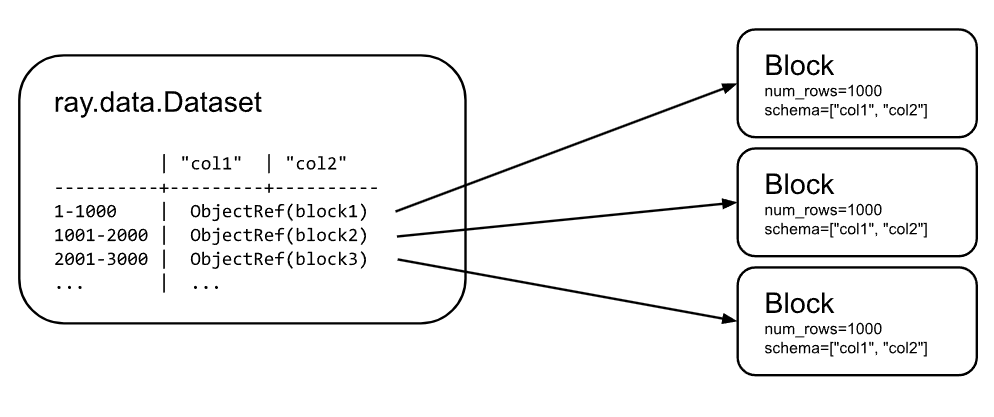

Source: [Ray docs](https://docs.ray.io/en/latest/data/key-concepts.html)

```python
materialized = events_ds.materialize()
print("Materialized blocks:", materialized.num_blocks())
print(materialized.stats())
```

[output not shown]

[output not shown]

```
2026-05-14 13:10:46,016	INFO streaming_executor.py:300 -- ✔️  Dataset dataset_0_0 execution finished in 2.02 seconds
```

[output not shown]

#### Execution is **lazy**: no data is manipulated unless explicitly required.

```python
sorted_ds = events_ds.sort(key='event_ts')
```

Why did this cell run instantly?

Ray Data built a plan:

1. Read the data from the source files, with different tasks reading different blocks.
2. Sort the rows by `event_ts`.

**It did not execute that plan yet.**

```python
sorted_ds.explain()
```

```
-------- Logical Plan --------
Sort[Sort]
+- Read[ReadParquet]

-------- Logical Plan (Optimized) --------
Sort[Sort]
+- Read[ReadParquet]

-------- Physical Plan --------
AllToAllOperator[Sort]
+- TaskPoolMapOperator[ReadParquet]
   +- InputDataBuffer[Input]

-------- Physical Plan (Optimized) --------
AllToAllOperator[Sort]
+- TaskPoolMapOperator[ReadParquet]
   +- InputDataBuffer[Input]
```

We can tell Ray to execute the plan explicitly.

```python
events_materialized = sorted_ds.materialize()
```

[output not shown]

- Some methods trigger execution (e.g. `show()`, `sum()`, `materialize()`).
- Some methods are lazy (e.g. `sort()`, `groupby()`, `groupby(...).aggregate()`).

If a method returns another `Dataset` or `GroupedData`, it is usually still lazy.

**Common footgun**: triggering execution unintentionally can dominate runtime.

## 2. Cheap vs expensive operations

In pandas, these often feel interchangeable:

```
df.methodA.methodB
df.methodB.methodA
```

With distributed data, the shape of the final execution plan matters much more.

**Important nuance:** Until the dataset is consumed or materialized, Ray is building a logical plan, optimizing it, and then lowering it to a physical plan. The optimizer may fuse or reorder operations when it preserves semantics.

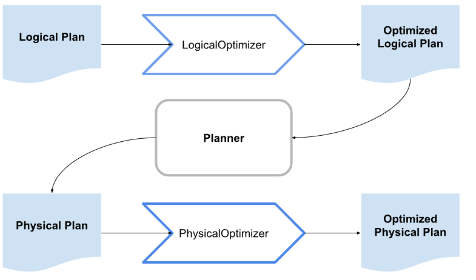

Source: [Ray docs](https://docs.ray.io/en/latest/data/key-concepts.html#operators-and-plans)

### Example: wide vs narrow sort

**Goal:** sort by `event_ts` and end with the same narrow columns, without `payload_blob`.

#### Option 1: sort wide, then drop `payload_blob`

```python
narrow_columns = [name for name in events_ds.schema().names if name != 'payload_blob']

wide_events = ray.data.read_parquet(str(input_dir), override_num_blocks=NUM_SHARDS)
start = time.perf_counter()

# This materialize() is an optimization boundary:
# Ray must execute the wide sort now, with payload_blob still present.
wide_sorted_with_blob = wide_events.sort('event_ts').materialize()

wide_sorted = wide_sorted_with_blob.select_columns(narrow_columns)
wide_elapsed = time.perf_counter() - start
```

[output not shown]

#### Option 2: drop `payload_blob` first

```python
narrow_events = ray.data.read_parquet(str(input_dir), override_num_blocks=NUM_SHARDS)
start = time.perf_counter()
narrow_sorted = (
    narrow_events
    .select_columns(narrow_columns)
    .sort('event_ts')
    .materialize()
)
narrow_elapsed = time.perf_counter() - start

print(f'wide sort elapsed: {wide_elapsed:.2f} s')
print(f'narrow sort elapsed: {narrow_elapsed:.2f} s')
print(f'wide / narrow ratio: {wide_elapsed / narrow_elapsed:.2f}x')
```

[output not shown]

```
wide sort elapsed: 0.44 s
narrow sort elapsed: 0.16 s
wide / narrow ratio: 2.71x
```

```python
# Run stats before any preview action like show() or take().
# Those actions record their own limit/iteration work in the dataset stats.
print(wide_sorted_with_blob.stats())
print('\n'+ '='*20+'\n')
print(narrow_sorted.stats())
```

```
Operator 1 ReadParquet: 8 tasks executed, 8 blocks produced in 0.07s
* Remote wall time: 14.19ms min, 40.27ms max, 30.63ms mean, 245.07ms total
* Remote cpu time: 15.62ms min, 46.88ms max, 29.3ms mean, 234.38ms total
* UDF time: 0us min, 0us max, 0.0us mean, 0us total
* Peak heap memory usage (MiB): 0.0 min, 0.0 max, 0 mean
* Output num rows per block: 7500 min, 7500 max, 7500 mean, 60000 total
* Output size bytes per block: 15431929 min, 15432845 max, 15432487 mean, 123459900 total
* Output rows per task: 7500 min, 7500 max, 7500 mean, 8 tasks used
* Tasks per node: 8 min, 8 max, 8 mean; 1 nodes used
* Operator throughput:
	* Total input num rows: 0 rows
	* Total output num rows: 60000 rows
	* Ray Data throughput: 804031.9522297174 rows/s
	* Estimated single task throughput: 244831.0053877847 rows/s

Operator 2 Sort: executed in 0.41s

	Suboperator 0 SortMap: 1 tasks executed, 8 blocks produced
	* Remote wall time: 7.38ms min, 27.99ms max, 21.06ms mean, 168.49ms total
	* Remote cpu time: 15.62ms min, 31.25ms max, 19.53ms mean, 156.25ms total
	* UDF time: 0us min, 0us max, 0.0us mean, 0us total
	* Peak heap memory usage (MiB): 0.0 min, 0.0 max, 0 mean
	* Output num rows per block: 7500 min, 7500 max, 7500 mean, 60000 total
	* Output size bytes per block: 15427239 min, 15428155 max, 15427797 mean, 123422380 total
	* Output rows per task: 60000 min, 60000 max, 60000 mean, 1 tasks used
	* Tasks per node: 1 min, 1 max, 1 mean; 1 nodes used
	* Operator throughput:
		* Total input num rows: 60000 rows
		* Total output num rows: 60000 rows
		* Ray Data throughput: 1816651.427573008 rows/s
		* Estimated single task throughput: 356110.9832340908 rows/s

	Suboperator 1 SortReduce: 1 tasks executed, 8 blocks produced
	* Remote wall time: 30.87ms min, 60.69ms max, 38.98ms mean, 311.86ms total
	* Remote cpu time: 15.62ms min, 62.5ms max, 33.2ms mean, 265.62ms total
	* UDF time: 0us min, 0us max, 0.0us mean, 0us total
	* Peak heap memory usage (MiB): 0.0 min, 0.0 max, 0 mean
	* Output num rows per block: 6204 min, 8815 max, 7500 mean, 60000 total
	* Output size bytes per block: 12765169 min, 18137369 max, 15431548 mean, 123452391 total
	* Output rows per task: 60000 min, 60000 max, 60000 mean, 1 tasks used
```

[output cut: 47 more lines]

```
	* Remote cpu time: 0.0us min, 0.0us max, 0.0us mean, 0.0us total
	* UDF time: 0us min, 0us max, 0.0us mean, 0us total
	* Peak heap memory usage (MiB): 0.0 min, 0.0 max, 0 mean
	* Output num rows per block: 4986 min, 11924 max, 7500 mean, 60000 total
	* Output size bytes per block: 266873 min, 637318 max, 400612 mean, 3204896 total
	* Output rows per task: 60000 min, 60000 max, 60000 mean, 1 tasks used
	* Tasks per node: 1 min, 1 max, 1 mean; 1 nodes used
	* Operator throughput:
		* Total input num rows: 60000 rows
		* Total output num rows: 60000 rows
		* Ray Data throughput: 14918322.15820732 rows/s
		* Estimated single task throughput: 2831911.8680887 rows/s

Dataset throughput:
	* Ray Data throughput: 617373.5078037982 rows/s
```

#### Reading the `stats()` output

- `ReadParquet` -> `Output size bytes`: did Ray read the wide payload column or only the projected columns?
- `Sort` -> `executed in ...`: how long did the global sort stage take?
- `SortMap` / `SortReduce` -> `Output size bytes`: how much data moved through the sort?

### Global aggregation is expensive

This is not another method-order example. The first run is a projection-only baseline. The second run uses the same projection, then adds `groupby(...).aggregate(...)`.

The outputs are intentionally different; compare the timings and stats only to isolate the extra cost of global aggregation.

```python
local_events = ray.data.read_parquet(str(input_dir), override_num_blocks=NUM_SHARDS)
start = time.perf_counter()
local_projected = (
    local_events
    .select_columns(['region', 'latency_ms', 'spend_usd'])
    .materialize()
)
local_elapsed = time.perf_counter() - start

grouped_events = ray.data.read_parquet(str(input_dir), override_num_blocks=NUM_SHARDS)
start = time.perf_counter()
region_summary = (
    grouped_events
    .select_columns(['region', 'latency_ms', 'spend_usd'])
    .groupby('region')
    .aggregate(
        Count(alias_name='events'),
        Mean('latency_ms', alias_name='mean_latency_ms'),
        Sum('spend_usd', alias_name='total_spend_usd'),
    )
    .materialize()
)
grouped_elapsed = time.perf_counter() - start

print(f'project-only baseline elapsed: {local_elapsed:.2f} s')
print(f'baseline + groupby(region).aggregate elapsed: {grouped_elapsed:.2f} s')
print(f'aggregation / baseline ratio: {grouped_elapsed / local_elapsed:.2f}x')
```

[output not shown]

```
project-only baseline elapsed: 0.11 s
baseline + groupby(region).aggregate elapsed: 3.48 s
aggregation / baseline ratio: 32.82x
```

```python
print(region_summary.stats())
display(region_summary.to_pandas().sort_values('region').reset_index(drop=True))
```

```
Operator 1 ReadParquet: 8 tasks executed, 8 blocks produced in 0.08s
* Remote wall time: 3.9ms min, 6.8ms max, 4.61ms mean, 36.89ms total
* Remote cpu time: 0.0us min, 15.62ms max, 3.91ms mean, 31.25ms total
* UDF time: 0us min, 0us max, 0.0us mean, 0us total
* Peak heap memory usage (MiB): 0.0 min, 0.0 max, 0 mean
* Output num rows per block: 7500 min, 7500 max, 7500 mean, 60000 total
* Output size bytes per block: 112629 min, 112997 max, 112847 mean, 902776 total
* Output rows per task: 7500 min, 7500 max, 7500 mean, 8 tasks used
* Tasks per node: 8 min, 8 max, 8 mean; 1 nodes used
* Operator throughput:
	* Total input num rows: 0 rows
	* Total output num rows: 60000 rows
	* Ray Data throughput: 745194.4274263884 rows/s
	* Estimated single task throughput: 1626302.7375113752 rows/s

Operator 2 HashAggregate(key_columns=('region',), num_partitions=8): executed in 3.28s

	Suboperator 0 HashAggregate(key_columns=('region',), num_partitions=8)HashAggregate(key_columns=('region',), num_partitions=8)_shuffle: 1 tasks executed, 8 blocks produced
	* Remote wall time: 2.76s min, 3.09s max, 2.9s mean, 23.22s total
	* Remote cpu time: 156.25ms min, 250.0ms max, 189.45ms mean, 1.52s total
	* UDF time: 0us min, 0us max, 0.0us mean, 0us total
	* Peak heap memory usage (MiB): 0.0 min, 0.0 max, 0 mean
	* Output num rows per block: 5 min, 5 max, 5 mean, 40 total
	* Output size bytes per block: 216 min, 216 max, 216 mean, 1728 total
	* Output rows per task: 40 min, 40 max, 40 mean, 1 tasks used
	* Tasks per node: 1 min, 1 max, 1 mean; 1 nodes used
	* Operator throughput:
		* Total input num rows: 60000 rows
		* Total output num rows: 40 rows
		* Ray Data throughput: 12.955399288976906 rows/s
		* Estimated single task throughput: 1.7223481588845762 rows/s

	Suboperator 1 HashAggregate(key_columns=('region',), num_partitions=8)HashAggregate(key_columns=('region',), num_partitions=8)_finalize: 1 tasks executed, 8 blocks produced
	* Remote wall time: 324.8us min, 14.01ms max, 6.71ms mean, 53.65ms total
	* Remote cpu time: 0.0us min, 31.25ms max, 7.81ms mean, 62.5ms total
	* UDF time: 0us min, 0us max, 0.0us mean, 0us total
	* Peak heap memory usage (MiB): 0.0 min, 0.0 max, 0 mean
	* Output num rows per block: 0 min, 2 max, 0 mean, 5 total
	* Output size bytes per block: 0 min, 64 max, 19 mean, 156 total
	* Output rows per task: 5 min, 5 max, 5 mean, 1 tasks used
	* Tasks per node: 1 min, 1 max, 1 mean; 1 nodes used
	* Operator throughput:
		* Total input num rows: 40 rows
		* Total output num rows: 5 rows
		* Ray Data throughput: 258.93587709535205 rows/s
		* Estimated single task throughput: 93.19108646431964 rows/s

Dataset throughput:
	* Ray Data throughput: 1.5811576603973527 rows/s
```

|  | region | events | mean_latency_ms | total_spend_usd |
| --- | --- | --- | --- | --- |
| 0 | APAC | 13149 | 94.100768 | 26101.919975 |
| 1 | EU | 16145 | 94.161103 | 35175.570000 |
| 2 | LATAM | 6135 | 93.943113 | 14611.759993 |
| 3 | MEA | 3065 | 94.057096 | 7100.019988 |
| 4 | NA | 21506 | 94.347624 | 47669.920018 |

#### Reading the `stats()` output

- Did projection pushdown work? Check `ReadParquet` -> `Output size bytes`. It should be small because `payload_blob` is not read here.
- Where is the time? Compare `ReadParquet` time with `HashAggregate(...): executed in ...`.
- Which part of aggregation dominates? Compare the `_shuffle` *(communication)* suboperator with `_finalize` *(local reduction)*.

**Conclusion**: projection is local; aggregation by key is global. `groupby(...).aggregate(...)` is expensive because Ray cannot finish the job block by block in isolation.

## 3. Custom aggregators

Building a custom aggregator exposes the same shuffle/reduction pattern used by the built-in aggregators:

1. Compute a small partial state inside each block.
2. Shuffle/repartition those partial states by group key.
3. Reduce the matching partial states locally.
4. Finalize the reduced state into the answer you want.

Input: rows with `region` and `spend_usd`.

Output: one row per `region` with `paid_event_rate`, the share of events where `spend_usd > 0`.

The implementation follows the four steps above:

1. `aggregate_block` scans one local chunk for a group and returns `[paid_events, total_events]`.
2. Ray shuffles those partial states so matching `region` keys are collocated.
3. `combine` locally reduces matching partial states by adding the two counts. It may be called multiple times as Ray merges partial accumulators for each key.
4. `finalize` turns the reduced `[paid_events, total_events]` state into `paid_events / total_events`.

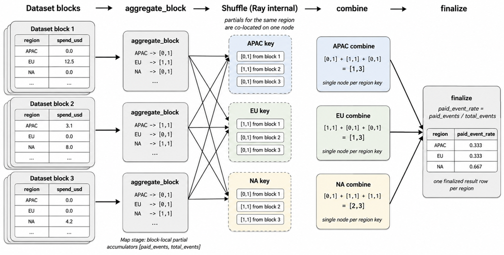

```python
class PaidEventRate(AggregateFnV2):
    def __init__(self):
        super().__init__(
            'paid_event_rate',
            on='spend_usd',
            ignore_nulls=False,
            zero_factory=lambda: [0, 0],
        )

    def aggregate_block(self, block):
        pdf = BlockAccessor.for_block(block).to_pandas()
        paid_event_mask = pdf['spend_usd'] > 0
        paid_events = int(paid_event_mask.sum())
        total_events = len(pdf)
        return [paid_events, total_events]

    def combine(self, current_accumulator, new_accumulator):
        current_paid_events, current_total_events = current_accumulator
        new_paid_events, new_total_events = new_accumulator

        return [
            current_paid_events + new_paid_events,
            current_total_events + new_total_events,
        ]

    def finalize(self, accumulator):
        paid_events, total_events = accumulator
        return paid_events / total_events


paid_rate_by_region = (
    events_ds
    .select_columns(['region', 'spend_usd'])
    .groupby('region')
    .aggregate(PaidEventRate())
)

display(paid_rate_by_region.to_pandas().sort_values('region').reset_index(drop=True))
```

[output not shown]

|  | region | paid_event_rate |
| --- | --- | --- |
| 0 | APAC | 0.067914 |
| 1 | EU | 0.069805 |
| 2 | LATAM | 0.079707 |
| 3 | MEA | 0.072104 |
| 4 | NA | 0.070817 |

## 4. Summary

This notebook only covered a high-level slice of Ray Data. The full API is broader, and it also works beyond tabular ETL workloads, including text, images, tensors, and batch inference pipelines.

The key ideas to keep are:

- Think in blocks, not individual rows.
- Ray Data builds and optimizes a lazy plan, so adjacent block-local operations may be fused or pushed earlier when it is safe. Still, the optimizer is limited so writing the plan in the most efficient order is healthy.
- Prefer block-local narrowing steps like `filter`, `select_columns`, and many `map_batches` transforms before all-to-all work.
- Methods like `sort()` and `groupby(...).aggregate(...)` are lazy, but when executed they become expensive global operations.
- `materialize()`, `show()`, `sum()`, `to_pandas()`, and often `count()` are the kinds of calls that force execution.
- If a later stage only needs a few columns, project early before the global op.
- Bring data back to pandas only when the result is genuinely small.

For a broader tour of the API, see the [Ray Data docs](https://docs.ray.io/en/latest/data/key-concepts.html) and the [Aggregating Data guide](https://docs.ray.io/en/latest/data/aggregating-data.html).